# An Analysis of factors that affect race completion times and probability of winning in Formula E

by Error 404: Tudor Cucu, Binxi Yang, Jiacheng Zhang, Mengchuan Sun

29 Nov 2023`

## Research Question

How do average race completion times vary over time and what factors affect the rank achieved by race drivers? This information could be used to predict which teams are more likely to win certain races and gain insights into how some teams build their cars.

## Data

We used the Formula E Championship dataset (referenced at the end of the document). This dataset was derived from Wikipedia race reports by the author. As such, there were various inconsistencies within the data, especially with regards to the time_retired variable. The main variables of interest for our investigation were the time_retired (detailing the time taken to complete the race), team, race_name (including the city in which the race took place as well as the year) and rank variables.

## Findings

We started off by tidying the data, creating a new variable called race_city which only included the name of the city the race took place in. We used this variable as a stand-in for the race track (which wasn’t included in the dataset) under the assumption that all races in the same city would take place on the same track.

The first step in our analysis was to create a graph showcasing the evolution of rank 1 times over the seasons in a few selected cities, which had the largest number of races in order to have as many data points as possible. We decided to plot separate lines for separate cities as the different lengths of different tracks may lead to false conclusions if they were all considered together. In order to do this, we had to modify the time_retired variable to a standard hms (lubridate) format and then into seconds, as the data for the rank 1 times was in a variety of different formats.

Our expectations were that rank 1 times would go down over the seasons as the drivers gain more experience with the tracks and as the technology in the cars advances. The plot for the following cities: Berlin, Marrakesh, Mexico City and Paris can be seen below.

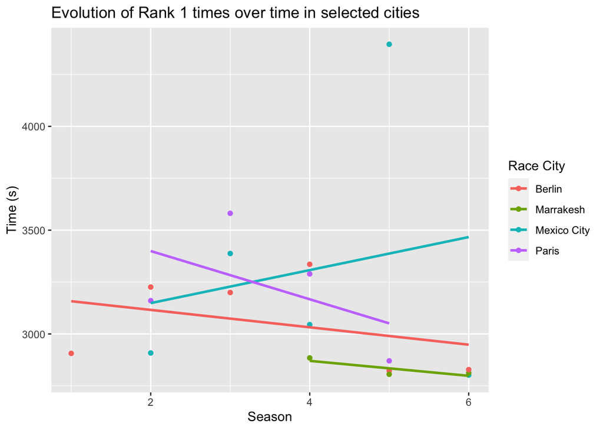

The lines of best fit seem to indicate that the rank 1 times decrease as expected (except for Mexico City), but on closer inspection it can be seen that the times increase on average in seasons 1-4, then drop drastically for seasons 5 and 6. The exceptions to this are Mexico City and Marrakesh. In season 5, the time for the Mexico City race increases drastically, resulting in the positive slope line of best fit. The Marrakesh races have pretty consistent rank 1 times which seem to slowly decrease as expected, but since there are only 3 races to go by there is a high level of uncertainty associated with this trend.

In order to obtain some more conclusive results, we decided to utilise all of the race times, rather than just the rank 1 times. This required even more data tidying as the times for every rank below rank 1 were defined in terms of the rank 1 time (for example +1.022s). Additionally, inconsistencies in the way the times were formatted resulted in more work that needed to be done to tidy the data. As such we had to manually modify times with unusual formats.

After all of the times were converted into seconds, we plotted a graph relating the mean time taken to complete a race against the date of the race and compared the results against the plot for the rank 1 times. We also decided to plot a few other statistics, but this didn’t result in any useful conclusions due to very high uncertainty values.

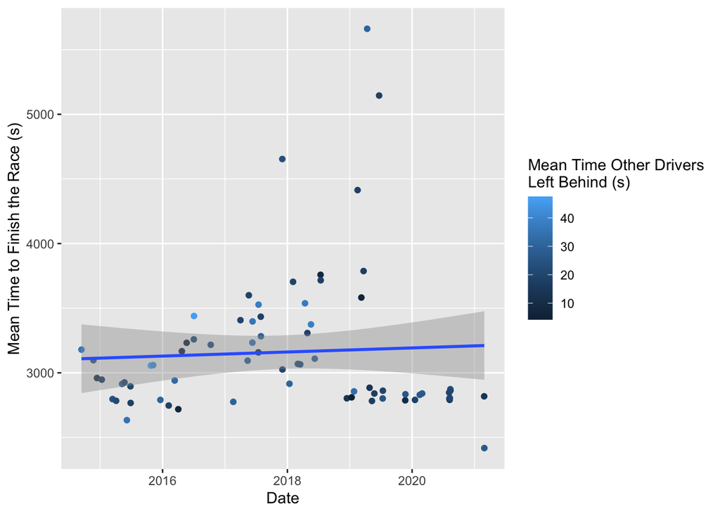

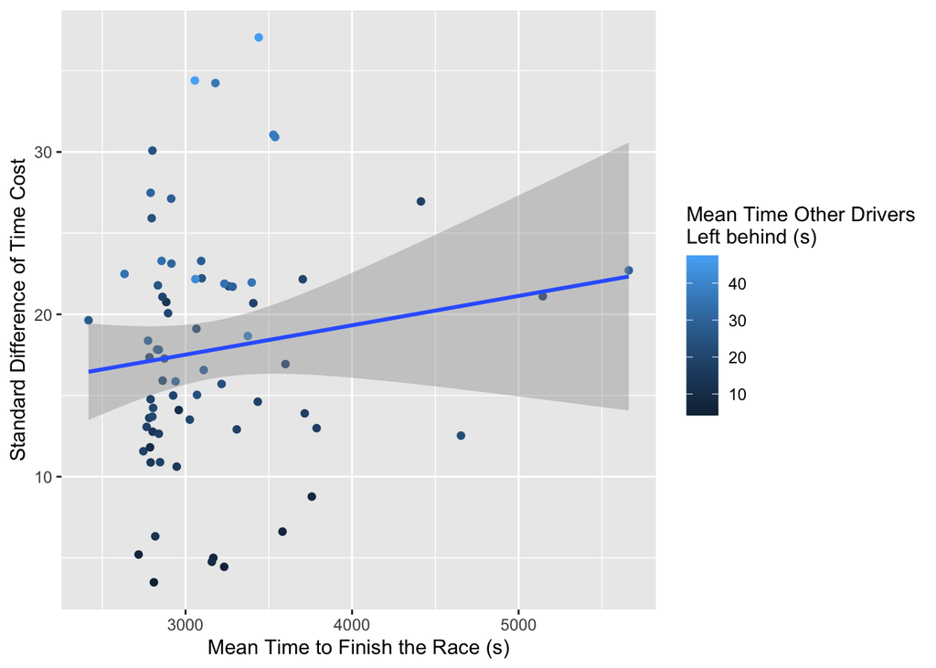

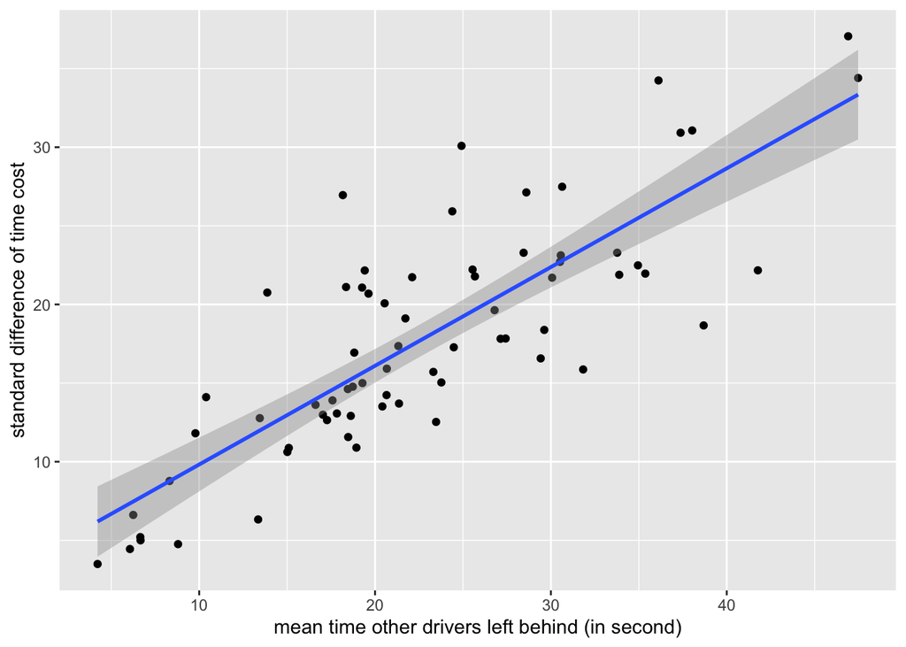

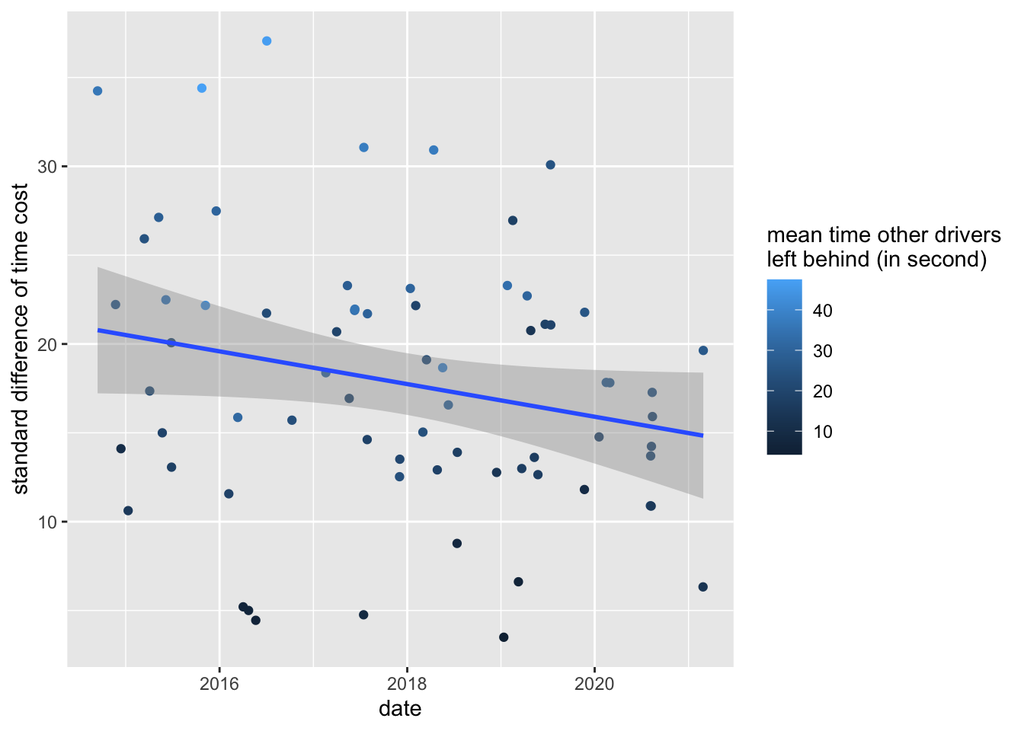

As we can see from the first graph, the mean time taken to finish a race seems to increase, before dropping off suddenly towards the end, and remaining fairly consistent. These findings seem to match up with the findings from the rank 1 times plot. It’s also important to note that the slope on this graph is once again affected by large values at the threshold before the average times drop. Additionally, it is worth noting that these graphs do not separate the times by the city in which the race took place, so this would be a possible point of further research, which may yield new results.

Another area which we wanted to conduct research in was whether different teams build their cars differently and how this would affect their probability of achieving a high rank on certain tracks. For example, if a team performs better on tracks with many long straight lines than on tracks with many turns, then it may suggest that this team builds cars with high top speed and acceleration in a straight line, but poorer maneuverability.

In order to do this, we selected two cities, Berlin and Mexico City, which had a larger number of races. Berlin is the straighter track with only 10 corners, whereas Mexico has 16. We then only selected the top 5 ranks for each race. The frequency that each team came up in the top 5 for each race was calculated and then divided by the number of races in each city to give the proportion of the races where that team ranked in the top 5, thus giving us a metric for the probability that a certain team will perform well on a certain track. Only teams that reached top 5 more than 20% of the time in either race were included in order to reduce clutter. Below we can see the resulting bar plot.

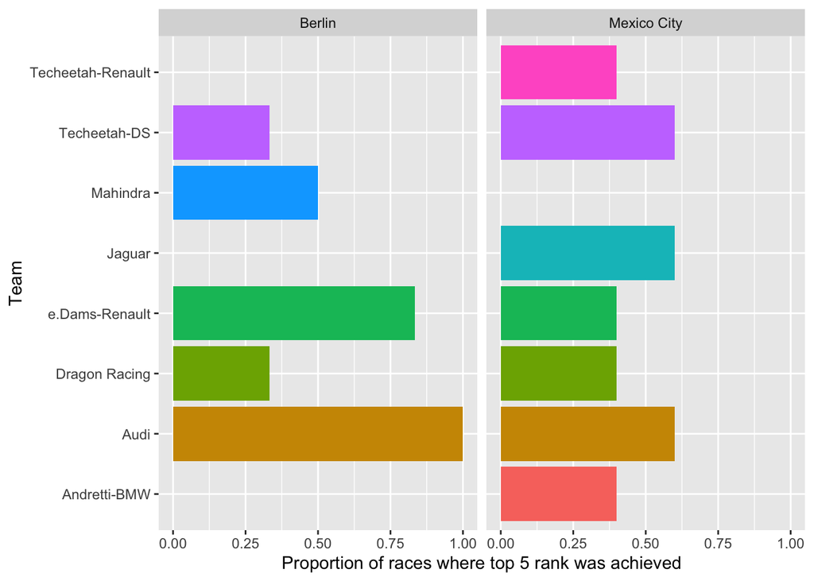

As expected, due to the large number of restrictions on specifications of cars, teams that performed well in one of the races, also tended to perform well in the other race. However, it is worth noting that teams like Andretti BMW, Jaguar and Techeetah Renault performed well in Mexico City, but never placed top 5 in Berlin and, vice versa, Mahindra, which performed well in Berlin, never reached top 5 in Mexico. This may suggest that the cars made by teams like Jaguar are built to perform better in races where maneuverability is more important. However, it is also important to note there is no reference to the ability of the drivers or how well they know certain tracks due to factors such as nationality. Additionally, this analysis assumes that the drivers for each team, as well as the team strategy in regards to how the cars are built have remained the same over the seasons. A possible area of further study could be an analysis of the performance of different drivers on different tracks.

Finally, we decided to build two different models, each investigating one of the two main areas where we conducted our research. The first model predicts the time_retired variable in terms of all the other variables. Firstly, the dataset was split in a 3:1 ratio between a training and testing set. The predictions from the model were then plotted against the values from the testing dataset and an r squared value was calculated. Below, we can see the plot of the predicted vs actual times and the r-squared value of the model. The red line is the model-predicted times and the green line represents the actual times.

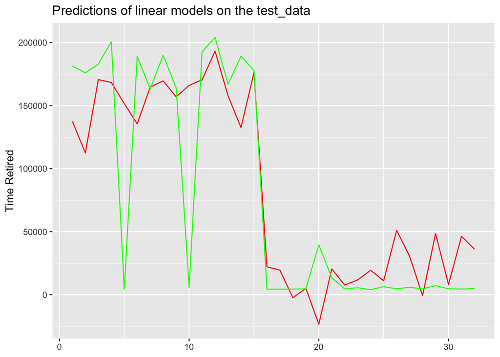

```
## [1] 0.7635778
```

As we can see from the graph, the model seems to predict the actual times quite well. Additionally, the relatively high r-squared value suggests that a high proportion of the variance is explained by the model. However, the model can still be improved.

The second model attempts to predict whether or not a driver will make it in the top 5 in a particular race. This model predicts this binary outcome in terms of all variables except rank, date, points and city. As before, the model was trained on the training dataset and tested on the testing dataset to avoid overplotting. Below we can see the ROC curve and the area under it.

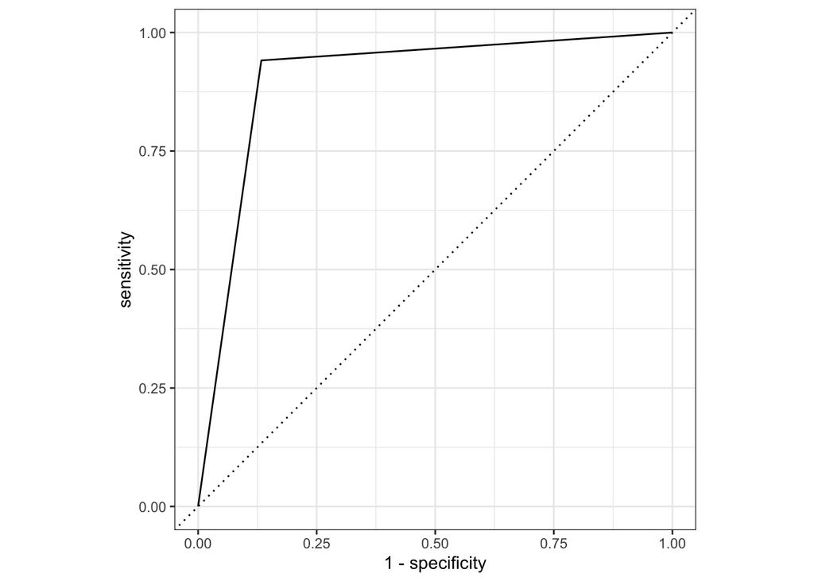

```
## # A tibble: 1 × 3
##   .metric .estimator .estimate
##   <chr>   <chr>          <dbl>
## 1 roc_auc binary         0.904
```

The ROC graph indicates that this model is quite effective, with an AUC value of 0.904.

## References

Dataset:

MLandry, 2020, Formula E Championship, Electronic Dataset, Kaggle.com, <20, Oct, 2023: https://www.kaggle.com/datasets/mlandry/formula-e-championship>

References:

Wikipedia, 2023, List of Formula E ePrix, Wikipedia, <26, Nov, 2023: https://en.wikipedia.org/wiki/List_of_Formula_E_ePrix>